# PRH Initialization

Max Czapanskiy

2018-08-22

Creating a pitch-roll-heading (PRH) file is a delicate process, dependent on device- and deployment-specific properties. The `goldbogenlab` package provides a set of (hopefully) useful tools to facilitate PRH creation. We begin by importing and cleaning raw data. This vignette will walk you through some common operations in PRH initialization.

We will use deployment *mn180607-44* as an example because it contains some common errors in the data. Please note that using the `goldbogenlab` package requires:

1. Your COPYCATS drive is available
2. The config file knows the path to the COPYCATS drive (see [set_cats_path()])

## Reading Raw Data

If your config file is properly set up, then all you need to provide are the `tagid` (i.e. *mn180607-44*) and `tagnum` (i.e. *44*). Make sure you have memory available beause the raw data will probably be *huge* (several GB). It’ll probably take a few minutes. You should see a progress bar and a warning that the timestamps are out of order.

```r
raw_prh <- init_prh("mn180607-44", "44")
```

```
#> Warning in import_cats(prh@tagid): Timestamps out of order.
```

It may seem redundant to supply both `tagid` and `tagnum`, but the latter isn’t always the last numbers of the former (e.g. *bp180525-44b*). `init_prh` will look for the `tagid` in the *tag_data_raw* folder and load the raw CSVs. Your data should look like:

```r
head(raw_prh@rawdata)
```

```
#> # A tibble: 6 x 34
#>   dateUTC  timeUTC dateLocal timeLocal  accX  accY  accZ  gyrX  gyrY  gyrZ
#>   <chr>    <chr>   <chr>     <chr>     <dbl> <dbl> <dbl> <dbl> <dbl> <dbl>
#> 1 07.06.2… 15:11:… 07.06.20… 08:11:06… -3.47 -1.33 -8.76  184.  535. -608.
#> 2 07.06.2… 15:11:… 07.06.20… 08:11:06… -3.41 -1.24 -8.71  184.  535. -608.
#> 3 07.06.2… 15:11:… 07.06.20… 08:11:06… -3.45 -1.18 -8.66  184.  535. -608.
#> 4 07.06.2… 15:11:… 07.06.20… 08:11:06… -3.40 -1.20 -8.71  184.  535. -608.
#> 5 07.06.2… 15:11:… 07.06.20… 08:11:06… -3.37 -1.19 -8.58  238.  620. -668.
#> 6 07.06.2… 15:11:… 07.06.20… 08:11:06… -3.37 -1.15 -8.64  238.  620. -668.
#> # ... with 24 more variables: magX <dbl>, magY <dbl>, magZ <dbl>,
#> #   tempIMU <dbl>, gpsDate <chr>, gpsTime <chr>, gps3 <int>,
#> #   gpsSats <int>, depthM <dbl>, depthDegC <dbl>, light1 <int>,
#> #   light2 <int>, syerr <chr>, battV <dbl>, battmA <dbl>, battmAh <dbl>,
#> #   camera <int>, flags <chr>, led <int>, camtime <int>, gpsL <lgl>,
#> #   ccStatus <chr>, ccVidSz <int>, datetimeUTC <dttm>
```

## Backskips

Deployment *mn180607-44* has a couple errors, including backskips and gaps. A backskip is when the timestamps skip forward and then backwards. Here’s an example:

```r
# Find backskips
timestamps <- raw_prh@rawdata$datetimeUTC
backskips <- which(lead(timestamps) < timestamps)
backskips
```

```
#> [1]  928327 2646500
```

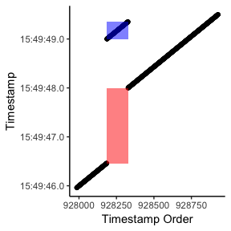

```r
# Find the boundaries around the first backskip
foreskips <- which(difftime(lead(timestamps), timestamps, units = "secs") > 1)
gap_begin <- timestamps[foreskips[1]]
backskip_begin <- timestamps[foreskips[1] + 1]
backskip_end <- timestamps[backskips[1]]
gap_end <- timestamps[backskips[1] + 1]

raw_prh@rawdata %>%
  mutate(timestamp_order = seq_along(datetimeUTC)) %>%
  filter(between(datetimeUTC,
                 gap_begin - seconds(0.5),
                 gap_end + seconds(1.5))) %>%
  ggplot(aes(timestamp_order, datetimeUTC)) +
  geom_point() +
  annotate("rect",
           xmin = foreskips[1], xmax = backskips[1] + 1,
           ymin = gap_begin, ymax = gap_end,
           fill = "red", alpha = 0.5) +
  annotate("rect",
           xmin = foreskips[1] + 1, xmax = backskips[1],
           ymin = backskip_begin, ymax = backskip_end,
           fill = "blue", alpha = 0.5) +
  scale_y_datetime(date_labels = "%H:%M:%OS1") +
  labs(x = "Timestamp Order",
       y = "Timestamp") +
  theme_classic()
```

Notice the timestamps recorded in the backskip (blue box) are duplicated later in the time series. Also, the duration of the timeskip is shorter than the gap around it (red box). That suggests we can’t trust the data in the timeskip or fix it by shifting the timestamps down. So we’ll delete those records and add new timestamps in the correct order using `fix_backskip`.

```r
fixbackskip_prh <- fix_backskip(raw_prh)
```

```
#> 2 backwards skip(s) found, longest duration 1.54 s.
```

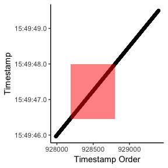

```r
timestamps <- fixbackskip_prh@rawdata$datetimeUTC
new_gap_end <- which(timestamps == gap_end)
fixbackskip_prh@rawdata %>%
  mutate(timestamp_order = seq_along(datetimeUTC)) %>%
  filter(between(datetimeUTC,
                 gap_begin - seconds(0.5),
                 gap_end + seconds(1.5))) %>%
  ggplot(aes(timestamp_order, datetimeUTC)) +
  geom_point() +
  annotate("rect",
           xmin = foreskips[1], xmax = new_gap_end,
           ymin = gap_begin, ymax = gap_end,
           fill = "red", alpha = 0.5) +
  scale_y_datetime(date_labels = "%H:%M:%OS1") +
  labs(x = "Timestamp Order",
       y = "Timestamp") +
  theme_classic()
```

Now the timestamps are in proper order and evenly distributed. Note the red box is much wider now due to filling in missing timestamps. There was also a warning with the number of backskips and the longest duration. If the longest duration backskip exceeds a threshold (by default 2s) then manual data processing will be necessary.